# 8-26 Class Notes

Sarah Cannon

2024-08-26

# Slides

Can be found on Canvas, in the Files section

# Overview of R, RStudio

R - programming language we’ll be using this semester

RStudio - the development environment (program) we’ll be using this semester to write code in R

Can run commands in console (bottom left by default), such as:

2+3 (outputs 5)

x <- 3 (stores the value 3 in a variable x, no output)

y <- 2 (stores the value 2 in variable y, no output)

x (outputs 3)

y (outputs 2)

x + y (outputs 5)

x - y (outputs 1)

Notes: - no output when storing a variable - can see current variables in the Environment panel (top right)

# RMarkdown

However, we’ll rarely use the console (except to install packages)

Instead, we’ll use RMarkdown

File > New > RMarkdown

Or, simply open a .rmd file (You can find these notes as “8-26 Class Notes.rmd” in the Files section of Canvas)

RMarkdown:

- A way of organizing code into a single file that you can run in chunks or run all at once (Similarish to Jupyter Notebooks)
- File > New File > RMarkdown. Files end in .rmd
- For now, delete default text after header
- Can insert code chunks in RMarkdown, and run commands there just like you would in the console by clicking green arrow

```r
3+2
```

```
## [1] 5
```

(Shortcut to insert code chunk: CTRL+ALT+I or CMD+Option+I)

- Can run multiple commands at once:

```r
x <- 3
y <- 2
x+y
```

```
## [1] 5
```

```r
x-y
```

```
## [1] 1
```

# Data and Plots

Just enough to get you started!

Look at built-in data set trees:

```r
trees
```

```
##    Girth Height Volume
## 1    8.3     70   10.3
## 2    8.6     65   10.3
## 3    8.8     63   10.2
## 4   10.5     72   16.4
## 5   10.7     81   18.8
## 6   10.8     83   19.7
## 7   11.0     66   15.6
## 8   11.0     75   18.2
## 9   11.1     80   22.6
## 10  11.2     75   19.9
## 11  11.3     79   24.2
## 12  11.4     76   21.0
## 13  11.4     76   21.4
## 14  11.7     69   21.3
```

[output cut: 17 more lines]

Get more information about the data set trees:

```r
?trees
```

Make a scatterplot with Girth and Height:

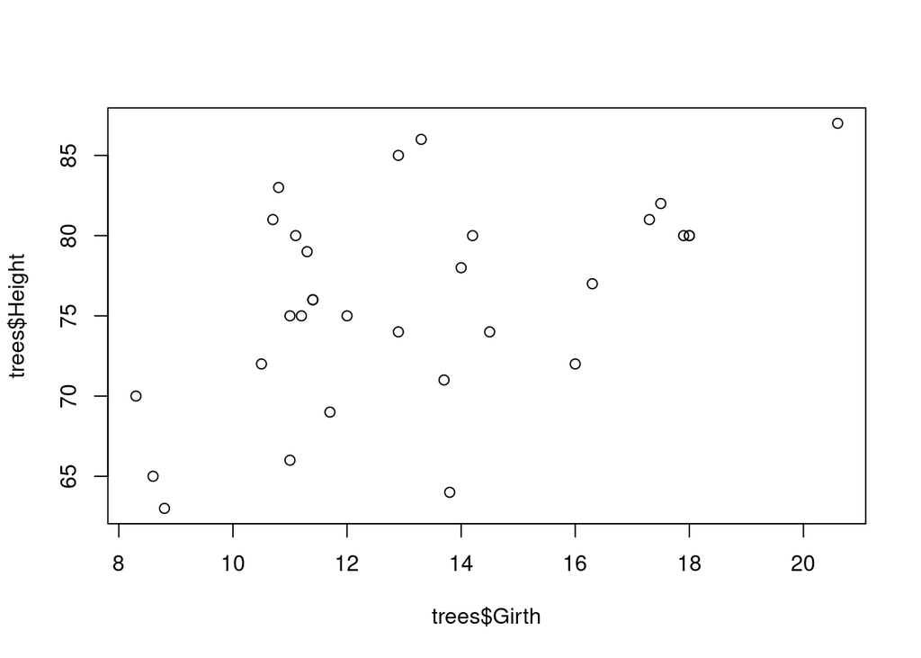

```r
plot(trees$Girth, trees$Height)
```

# Knitting

Produces a nice version of your document, with both text and code! We’ll talk more about knitting in the second class.

# Activity

Classes will end with an activity! Find it on Canvas, in the Files section (“8-26 Activity.pdf”)